# ggnetworkmap

Amos Elberg

January 10, 2015

This is the homepage for `ggnetworkmap`, a function for plotting elegant maps using `ggplot2`. `ggnetworkmap` is under consideration for inclusion in `GGally`.

`ggnetworkmap` builds on `ggnet`, first by fixing the issue with `ggnet` that caused me to develop `ggmapnetwork`: `ggnet` does not allow drawing the network over a map. `ggnetworkmap` does, and is particularly intended for use with `ggmap`. Some examples appear below:

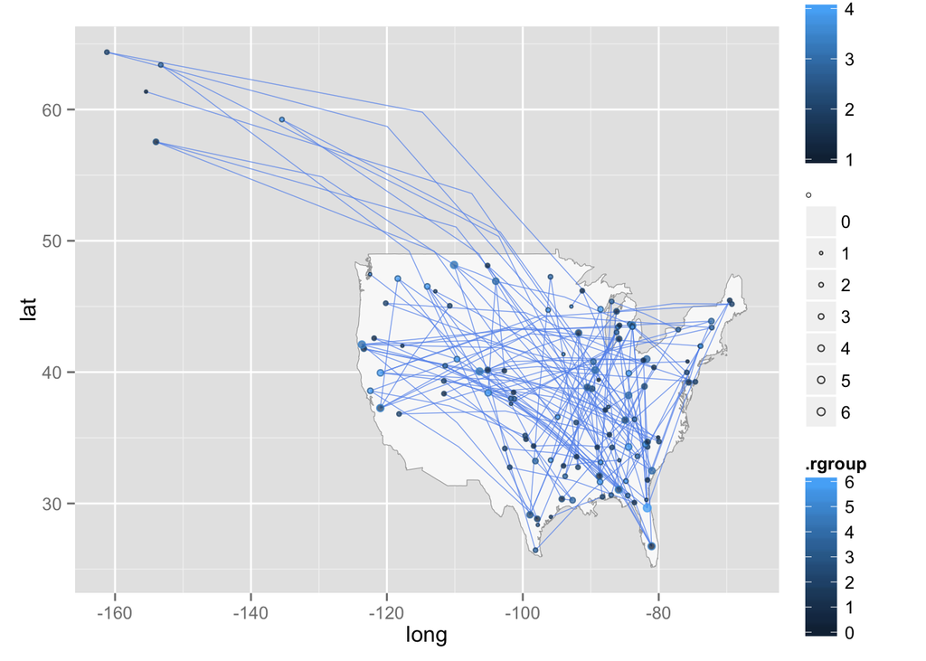

```r
graph <- graph.data.frame(flights, airports, directed = TRUE)

# Subset the graph
graph <- graph - V(graph)[degree(graph, mode = "total") < 2]

# Add vertex attributes that will be used to color nodes
V(graph)$degree <- degree(graph, mode = "total")
V(graph)$mygroup <- sample(1:4, length(V(graph)), replace = TRUE)

# Create the map
usa <- ggplot(ggplot2::map_data("usa"), aes(x = long, y = lat)) +
    geom_polygon(aes(group = group), color = "grey65",
                             fill = "#f9f9f9", size = 0.2)

# Draw the plot
ggnetworkmap(usa, graph, size = 2, great.circles = TRUE,
                         node.group = mygroup,
                         ring.group = degree,
                         segment.color = "cornflowerblue",
                         weight = degree)
```

This next example uses data from a spam community I identified on twitter while exploring and trying to clear-up a group of tweets. After coloring the nodes based on igraph’s information centrality community detection function, the odd structure stood out clearly.

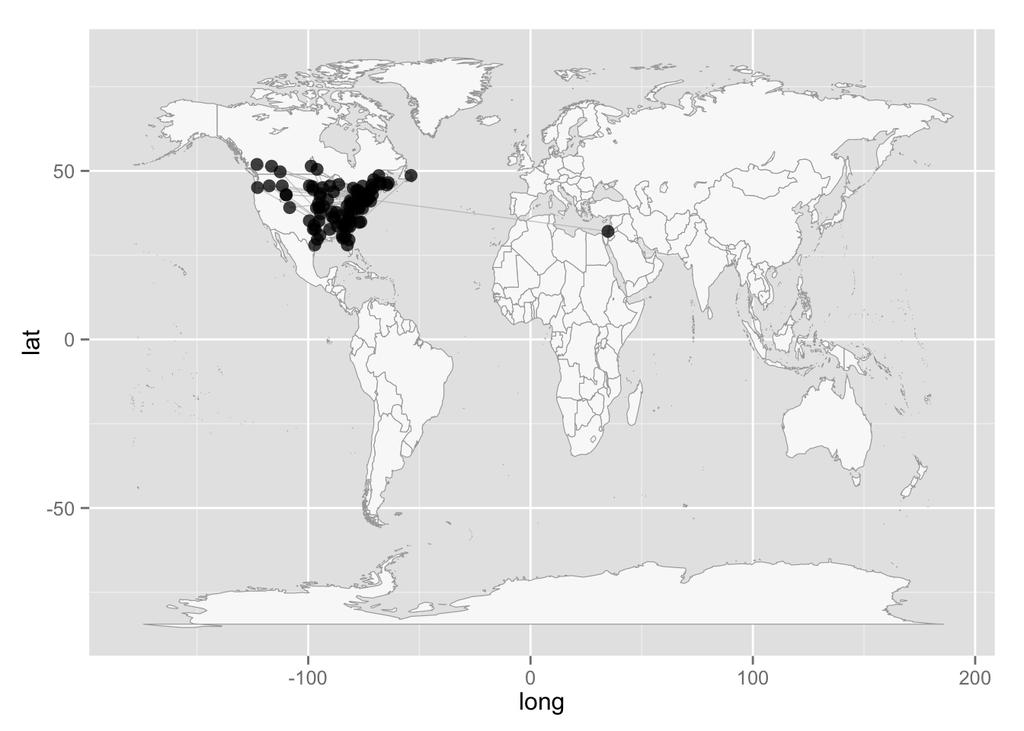

```r
data(twitter_spam_community)
world <- fortify(map("world", plot = FALSE, fill = TRUE))
gp <- ggplot(world, aes(x = long, y = lat)) +
geom_polygon(aes(group = group), color = "grey65",
                         fill = "#f9f9f9", size = 0.2)

ggnetworkmap(gp, twitter_spam_community)
```

Is the network really concentrated in the U.S.? Probably not. One of the odd things about the network, is a much higher proportion of the users gave locations that could be geocoded, than twitter users generally.

Let’s see the network topology

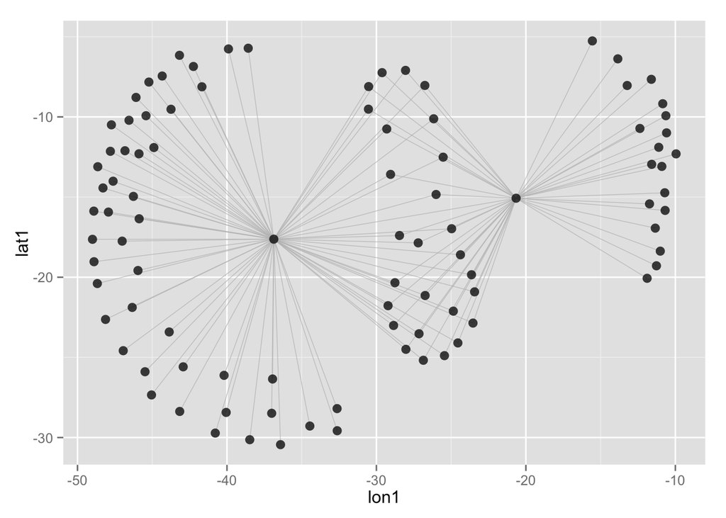

```r
ggnetworkmap(data=twitter_spam_community)
```

That’s an odd structure, let’s see who’s following who.

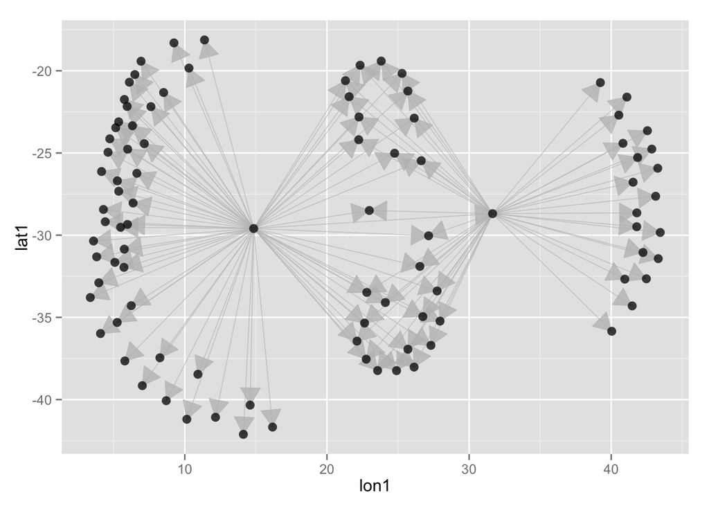

```r
ggnetworkmap(data=twitter_spam_community, arrow.size = 0.5)
```

Coloring nodes according to vertex attributes can highlight network structures.

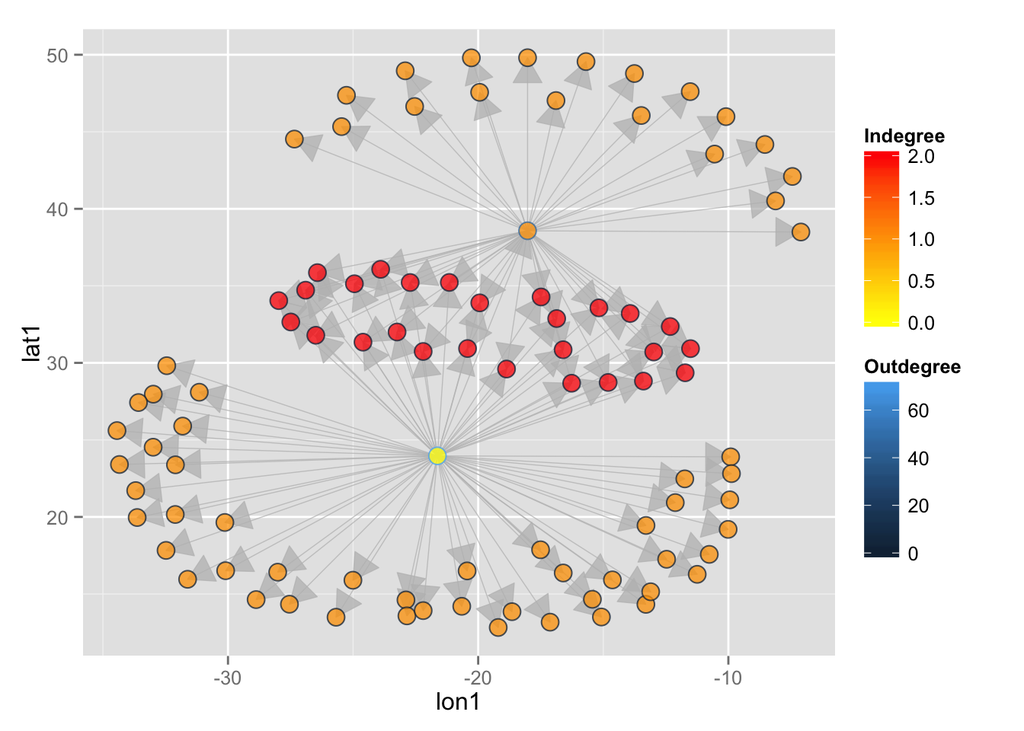

```r
V(twitter_spam_community)$indegree <- igraph::degree(twitter_spam_community, mode = "in")
V(twitter_spam_community)$outdegree <- igraph::degree(twitter_spam_community, mode = "out")

ggnetworkmap(data=twitter_spam_community,
                        arrow.size = 0.5,
                        node.group = indegree,
                        ring.group = outdegree, size = 4) +
                        scale_fill_continuous("Indegree", high = "red", low = "yellow") +
                        labs(color = "Outdegree")
```

Some of the twitter data is already contained as vertex attributes

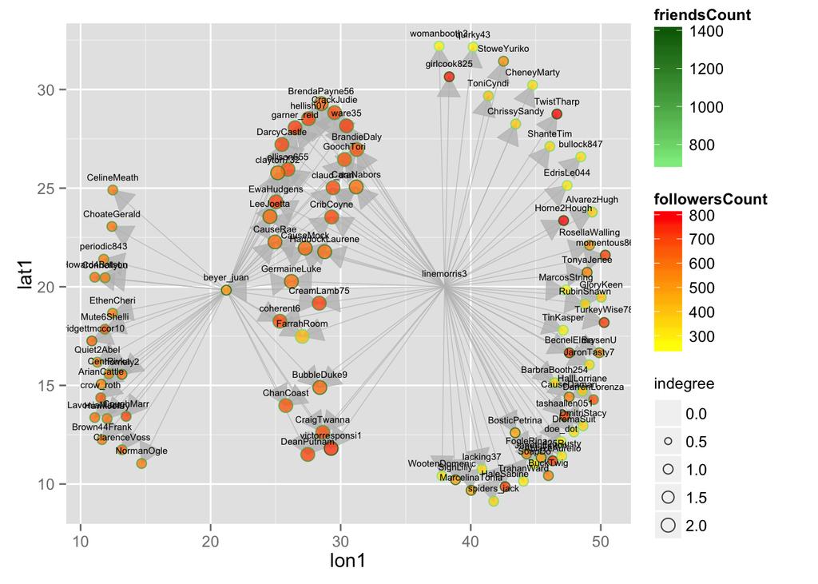

```r
ggnetworkmap(data=twitter_spam_community,
                        arrow.size = 0.5,
                        node.group = followersCount,
                        ring.group = friendsCount,
                        size = 4,
                        weight = indegree,
                        label.nodes = TRUE, vjust = -1.5) +
        scale_fill_continuous("followersCount", high = "red", low = "yellow") +
        labs(color = "friendsCount") +
        scale_color_continuous(low = "lightgreen", high = "darkgreen")
```